# San Francisco Rentals (2022-07-05)

DSA Group 72325

2023-11-17

# Analysis on San Francisco Rentals

| Name | Matriculation Number |
| --- | --- |
| Joel Lo Liang Ze | A0234274H |
| Lim Tze Cherng Ethan | A0233622N |
| Mathumita Raju | A0245499L |
| Tan Jing Kai, Brian | A0233495Y |
| Zhu Yiran | A0258237X |

## Introduction

San Francisco Rentals data shows new construction activities, rental prices (in USD) and building permits of the San Francisco Bay Area from 1990 to 2018. The Bay Area’s nine counties are Alameda, Contra Costa, Marin, Napa, San Francisco, San Mateo, Santa Clara, Solano, and Sonoma. The San Francisco Rentals data of `rent`, `permits` and `new_construction` comes from Kate Pennington through web scraping craigslist, data.sfgov.org and Vital Signs respectively. In this project, we are looking to answer the following question regarding rental prices in San Francisco:

- **What are some possible determinants that affect rental price in San Francisco?**

To investigate this, we will utilize the primary data set: `rent` on San Francisco Rentals from 2000 to 2018 obtained from [tidytuesday/data/2022/2022-07-05/](https://github.com/rfordatascience/tidytuesday/blob/master/data/2022/2022-07-05).

```r
rent <- readr::read_csv('https://raw.githubusercontent.com/rfordatascience/tidytuesday/master/data/2022/2022-07-05/rent.csv')

# summary(rent)
```

A brief description of the variables **relevant** to our analysis are given in the tables below:

### Rent

The key variables we will utilise from the `rent` dataset are `year`, `county`, `price`, `sqft`, `lat` and `lon`. These variables provide information on the year the rental unit’s advertisement was placed, counties the rental units are located in, their rental prices, their interior areas, and their geographical coordinates.

| Variable | Class | Description |
| --- | --- | --- |
| year | double | year the rental is posted in |
| county | character | county the rental is posted in |
| price | double | monthly rental price in USD |
| sqft | double | interior area of rental apartment in square feet |
| lat | double | latitude (paired with with longitude to give location) |
| lon | double | longitude (paired with with latitude to give location) |

### Grouping of counties

Conventionally, the nine-county Bay Area can be divided further into sub-regions based on their geographical locations: East Bay, North Bay, the city of San Francisco, San Francisco Peninsula, and South Bay. The counties that fall under the five sub-regions are detailed in the following table. We would be following this grouping of counties for all of our visualisations.

| Sub-Region | County/Counties |
| --- | --- |
| East Bay | Contra Costa, Alameda |
| North Bay | Sonoma, Napa, Solano, Marin |
| San Francisco City | San Francisco |
| San Francisco Peninsula | San Mateo |
| South Bay | Santa Clara |

## Data Cleaning and Summary

The relevant columns were selected from the `rent` dataset and grouped by Sub-Region to form three new data frames for data visualisation. Moreover, only rows containing no NA values from year 2000 to year 2018 are considered. `santa cruz` county is excluded as it is not part of the Bay Area. The Average Rental Prices per Sub-Region per Year, Geospatial Location of the Rental and Rental Prices per Square Feet per Sub-Region are the 3 data frames derived from the `rent` dataset to plot how price varies with time, location and rental size.

### Average Rental Prices per Sub-Region per Year

The columns `year`, `county`, `price` is selected from `rent` to plot average rental prices of the sub-region from year 2000 to year 2018. The summary table below shows the ranges of average rental prices and the minimum starting year per sub-region. It is to be noted that the minimum year for San Francisco Peninsula is year 2001 and not year 2000 as there are no rental postings in San Mateo in year 2000.

```r
average_rental_prices <- rent %>%
  # Selection of relevant columns from the rent dataset for visualisation
  select(year, county, price) %>%
  # Excluding county not part of the Bay Area
  filter(county != "santa cruz") %>%
  # Use only data from 2000 to 2018
  filter(2000<=year & year<=2018) %>%
  # Omitting of NA values
  na.omit() %>%
  # Grouping counties into their respective sub-regions under a new "sub_region" column
  mutate(sub_region = case_when(county == "alameda" | county == "contra costa" ~ "East Bay",
                     county == "sonoma" | county == "napa" | county == "marin" | county == "solano" ~ "North Bay",
                     county == "san mateo" ~ "San Francisco Peninsula",
                     county == "san francisco" ~ "San Francisco",
                     county == "santa clara" ~ "South Bay")) %>%
  # Grouping the variables for visualisation later on
  group_by(sub_region, year) %>%
  # Calculate average rental price for each year in each county
  summarise(rental_average = mean(price))

# Printing a summary of the cleaned rental prices data frame
average_rental_prices %>%
  group_by(sub_region) %>%
  summarise(`min year` = min(year), `max year` = max(year), `min avg price` = min(rental_average), `max avg price`= max(rental_average)) %>%
  ungroup()
```

```
## # A tibble: 5 × 5
##   sub_region              `min year` `max year` `min avg price` `max avg price`
##   <chr>                        <dbl>      <dbl>           <dbl>           <dbl>
## 1 East Bay                      2000       2018           1029.           2622.
## 2 North Bay                     2000       2018           1230            3029.
## 3 San Francisco                 2000       2018           1666.           3948.
## 4 San Francisco Peninsula       2001       2018           1464.           3295.
## 5 South Bay                     2000       2018           1312.           3003.
```

### Geospatial Location of Rentals

The columns `county`, `price`, `lat`, `lon` is selected from `rent` to plot the geospatial locations of rentals from year 2000 to year 2018. The location data is rebounded to the San Francisco Bay Area of 36.8 < latitude < 38.8 and -123.5 < longitude < -121. The longitudinal values were found to be shifted by 0.03 and would not fit into our map plot, hence the correction was added after visually plotting the rental location.

```r
# Preparing a vector containing counties of interest for filtering
county_rentals <- c("alameda","contra costa","marin","napa","san francisco","san mateo","santa clara","solano","sonoma")

# Extracting coordinates from the maps package for the boundaries of counties of interest
county_coords <- map_data("county") %>%
  filter(subregion %in% county_rentals) %>%
  # Grouping counties into their respective regions under a new "region" column
  mutate(sub_region = case_when(subregion == "alameda" | subregion == "contra costa" ~ "East Bay",
                     subregion == "sonoma" | subregion == "napa" | subregion == "marin" | subregion == "solano" ~ "North Bay",
                     subregion == "san mateo" ~ "San Francisco Peninsula",
                     subregion == "san francisco" ~ "San Francisco",
                     subregion == "santa clara" ~ "South Bay"))

# Creating new data frame for rental prices, longitude and latitude
rentals_and_coords <- rent %>%
  # Excluding county not part of the Bay Area
  filter(county != "santa cruz") %>%
  # Use only data from 2000 to 2018
  filter(2000<=year & year<=2018) %>%
  # Filtering rental listings within the area of interest - the 5 regions, there were
  # several values far outside of the area of interest
  filter(lat > 36.8, lat < 38.8, lon > -123.5, lon < -121) %>%
  # Selection of relevant columns from the rent dataset for visualization
  select(price, lat, lon) %>%
  # Filtering out the listings that were outliers
  filter(price < quantile(price, 0.75) + 1.5 * IQR(price)) %>%
  # Adjusting the longitude values slightly as the locations of rental listings
  # were deviating slightly to the left (spatial correction for visualization)
  mutate(lon = lon + 0.03) %>%
  # Omitting NA values
  na.omit()

# Printing a summary of the data frame containing rental prices and coordinates
rentals_and_coords %>%
  summarise(`min price` = min(price), `max price`= max(price),
            `min lat` = min(lat), `max lat` = max(lat),
            `min lon` = min(lon), `max lon` = max(lon)
            )
```

```
## # A tibble: 1 × 6
##   `min price` `max price` `min lat` `max lat` `min lon` `max lon`
##         <dbl>       <dbl>     <dbl>     <dbl>     <dbl>     <dbl>
## 1         400        5850      37.0      38.8     -123.     -121.
```

### Rental Prices per Square Feet per Sub-Region

The columns `county`, `price`, `size` is selected from `rent` to plot the rental prices per square feet per sub-region from year 2000 to year 2018. The smallest rental is 90 square feet in San Francisco which is roughly a small 1 room apartment while the largest rental is 2246 square feet in North Bay which is roughly a large 4 room house.

```r
# Setting seed for reproducibility
set.seed(72325)
rental_prices_size <- rent %>%
  # Excluding county not part of the Bay Area
  filter(county != "santa cruz") %>%
  # Use only data from 2000 to 2018
  filter(2000<=year & year<=2018) %>%
  # Grouping the counties into their respective regions
  mutate(sub_region = case_when(county == "alameda" | county == "contra costa" ~ "East Bay",
                     county == "sonoma" | county == "napa" | county == "marin" | county == "solano" ~ "North Bay",
                     county == "san mateo" ~ "San Francisco Peninsula",
                     county == "san francisco" ~ "San Francisco",
                     county == "santa clara" ~ "South Bay")) %>%
  # Selection of relevant columns from the rent dataset for visualization
  select(sub_region, price, sqft) %>%
  # Omitting NA values
  na.omit() %>%
  # Exclusion of outliers as several outliers had extreme values that negatively
  # impacted quality of visualizations
  filter(sqft < quantile(sqft, 0.75) + 1.5 * IQR(sqft)) %>%
  # Sampling of 1000 records to prevent cluttering of points in scatter plot
  sample_n(1000)

# Printing a summary of the data frame containing rental prices and sizes
# of rental listings in square feet
rental_prices_size %>%
  group_by(sub_region) %>%
  summarise(`min price` = min(price), `max price` = max(price),
            `min size` = min(sqft), `max size`= max(sqft)
            ) %>%
  ungroup()
```

```
## # A tibble: 5 × 5
##   sub_region              `min price` `max price` `min size` `max size`
##   <chr>                         <dbl>       <dbl>      <dbl>      <dbl>
## 1 East Bay                        500        4500        150       2200
## 2 North Bay                       590        6000        220       2246
## 3 San Francisco                   600        9495         90       2000
## 4 San Francisco Peninsula         667        4750        425       1950
## 5 South Bay                       600        9500        240       2200
```

## Data Visualizations

### Plotting Average Housing Rental Prices in the Bay Area (2000-2018)

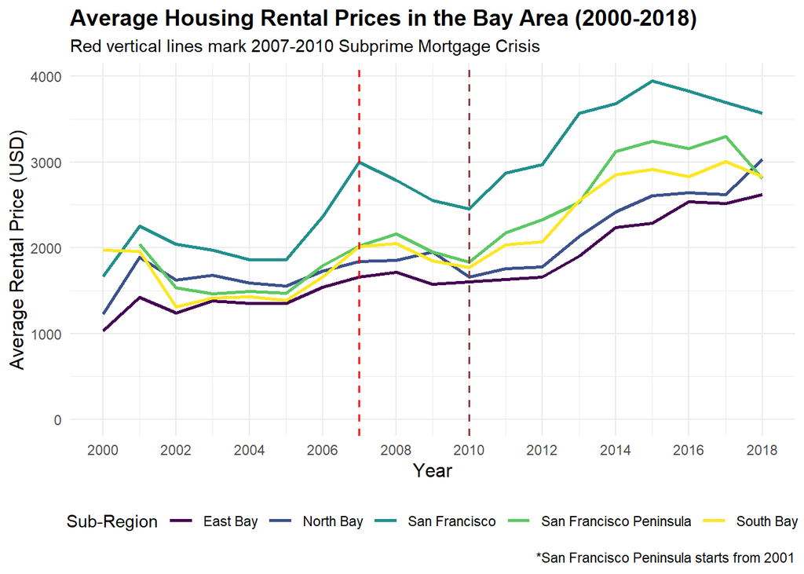

```r
annual_rent_price_plot = average_rental_prices %>%
  ggplot(aes(x = year, y = rental_average, colour = sub_region)) +
  geom_line(linewidth = 1) +
  theme_minimal() +
  scale_colour_viridis_d() +
  ylim(0, max(average_rental_prices$rental_average)) +
  scale_x_continuous(breaks = seq(min(average_rental_prices$year), max(average_rental_prices$year), 2)) +
  geom_vline(xintercept = 2007, linetype = 2, color = "red", size = 0.6) +
  geom_vline(xintercept = 2010, linetype = 2, color = "indianred4", size = 0.6) +
  labs(
    color = "Sub-Region",
    x = "Year",
    y = "Average Rental Price (USD)",
    title = "Average Housing Rental Prices in the Bay Area (2000-2018)",
    subtitle = "Red vertical lines mark 2007-2010 Subprime Mortgage Crisis",
    caption = "*San Francisco Peninsula starts from 2001"
  ) +
  theme(
    plot.title = element_text(size = 14, face = "bold"),
    axis.title = element_text(size = 12),
    legend.position = "bottom")

annual_rent_price_plot
```

This visualization illustrates the changes in **average rental prices** of rental listings grouped to their respective **sub-regions** against a **time period** between 2000 to 2018. Since the type of information represented here is time-series data, a line chart is useful to portray how a continuous variable (in this case, average rental price) changes over time in a simple yet informative manner.

### Plotting Prices of Rental Listings and their Locations

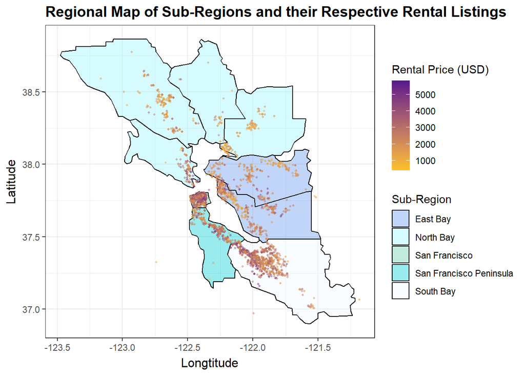

```r
point_colors <- colorRampPalette(c("goldenrod1", "purple4"))(n = 50)

map_plot <- ggplot(data = county_coords) +
  theme_bw() +
  scale_color_gradient(low = point_colors[1], high = point_colors[50]) +
  theme(
    plot.title = element_text(size = 14, face = "bold"),
    axis.title = element_text(size = 12),
    axis.title.y = element_text(margin = margin(r = 5)),
    axis.title.x = element_text(margin = margin(t = 5))) +
  geom_polygon(aes(x = long, y = lat, group = subregion, fill = sub_region),
               color = "black", alpha = 0.4) +
  scale_fill_manual(values = c("cornflowerblue","cadetblue1","aquamarine3","darkturquoise","aliceblue")) +
  geom_point(data = rentals_and_coords, aes(x = lon, y = lat, color = price),
             shape = 16, alpha = 0.5, size = 0.8) +
  labs(title = "Regional Map of Sub-Regions and their Respective Rental Listings",
       x = "Longtitude", y = "Latitude",
       color = "Rental Price (USD)", fill = "Sub-Region")

map_plot
```

This geospatial map visualization illustrates the variations in **rental prices** of individual rental listings based on their exact **geographical coordinates (latitude and longitude)**. A geospatical visualization is useful in this case, as it plots data against a background map of California, which might allow for certain trends to be identified that may not be apparent in a tabular or non-spatial presentation.

### Plotting the Relationship between Size of Rental Units and Rental Prices

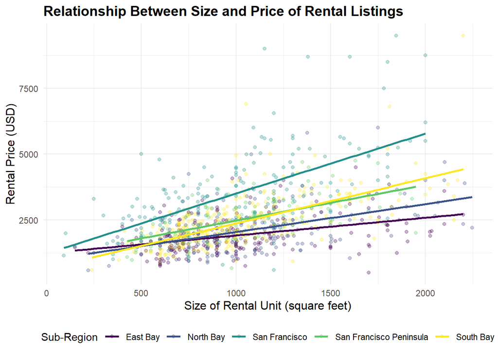

```r
sqft_price_plot <- ggplot(rental_prices_size, aes(x = sqft, y = price, color = sub_region)) +
  geom_point(alpha = 0.3) +
  geom_smooth(aes(color = sub_region), method = "lm", se = FALSE, linetype = "solid", linewidth = 1) +
  labs(
    color = "Sub-Region",
    x = "Size of Rental Unit (square feet)",
    y = "Rental Price (USD)",
    title = "Relationship Between Size and Price of Rental Listings") +
  theme_minimal() +
  scale_colour_viridis_d() +
  theme(
    plot.title = element_text(size = 14, face = "bold"),
    axis.title = element_text(size = 12),
    legend.position = "bottom")

sqft_price_plot
```

This visualization investigates on the relationships between the **rental prices** and **interior area in square feet** (an indicator for size of the unit) of rental listings, grouped according to their respective **sub-regions**. Since rental prices and interior area are both continuous variables, a scatter plot is useful for illustrating how they are related to each other. Additionally, a scatter plot can provide hints to the linearity of the relationship between variables, through the use of a regression line.

## Discussion

Through the visualizations, we are able to conclude that there are strong correlations between the three explored factors (time, location, and size) and rental prices in San Francisco.

### Prices of Rental Listings and their Locations

Other determinants such as location and size of units were explored as well. From the second visualization, we see that rent is notably higher within dense residential areas such as San Francisco, San Francisco Peninsula and South Bay regions, as compared to the more distant suburban regions. From this, we can determine that the location, and moreover proximity to city centers play a crucial role in influencing rental prices. This is aligned with the literature, where Barton (2011) found that land was a significant determinant in rent prices in California housing.

We have also noticed some outliers which have coordinates located in the sea, suggesting errant listings. These data were not removed as they possess minimal disruption to the visualization.

### Relationship between Size of Rental Units and Rental Prices

Finally, from the third visualization, we see that rental prices also increase with the size of rental units for all sub-regions. A noticeable difference is the rate of increase, where San Francisco has the steepest gradient compared to other sub-regions. From this, we can infer that size is a key determinant of rental prices in all sub-regions and has a larger effect on rental prices in San Francisco specifically.

## References

Barton, S. E. (2011). Land rent and housing policy: A case study of the San Francisco Bay Area rental housing market. *American Journal of Economics and Sociology*, 70(4), 845-873.

Pennington, Kate (2018). Bay Area Craigslist Rental Housing Posts, 2000-2018. Retrieved from https://github.com/katepennington/historic_bay_area_craigslist_housing_posts/blob/master/clean_2000_2018.csv.zip

United States Bureau of Labor Statistics (2023). *Consumer Price Index*. Retrieved from: https://www.bls.gov/cpi/